# Experiment 2 Analysis

**Sean Trott and Benjamin Bergen**  
2019

# Introduction

In Experiment 2, we asked whether:

1. A speaker’s knowledge state (implied or explicitly stated) predicted participants’ pragmatic interpretations.
2. Individual differences in *mentalizing* predicted the effect in (1), for both *explicit* and *implicit* deliveries of knowledge.

# Load data

```r
# setwd("/Users/seantrott/Dropbox/UCSD/Research/IndirectSpeechActs/2019_mentalizing_data/Experiment2")
main_plus_sst = read_csv("data/exp2_aggregated.csv")
main_plus_sst$answer = factor(main_plus_sst$answer)
```

# Results

## Does speaker knowledge predict pragmatic interpretation?

We asked whether a speaker’s awareness of an obstacle predicted participants’ likelihood of thinking they were making a request. We also manipulated *knowledge delivery*: whether or not information about the speaker’s knowledge state was given explicitly, or required readers to infer it.

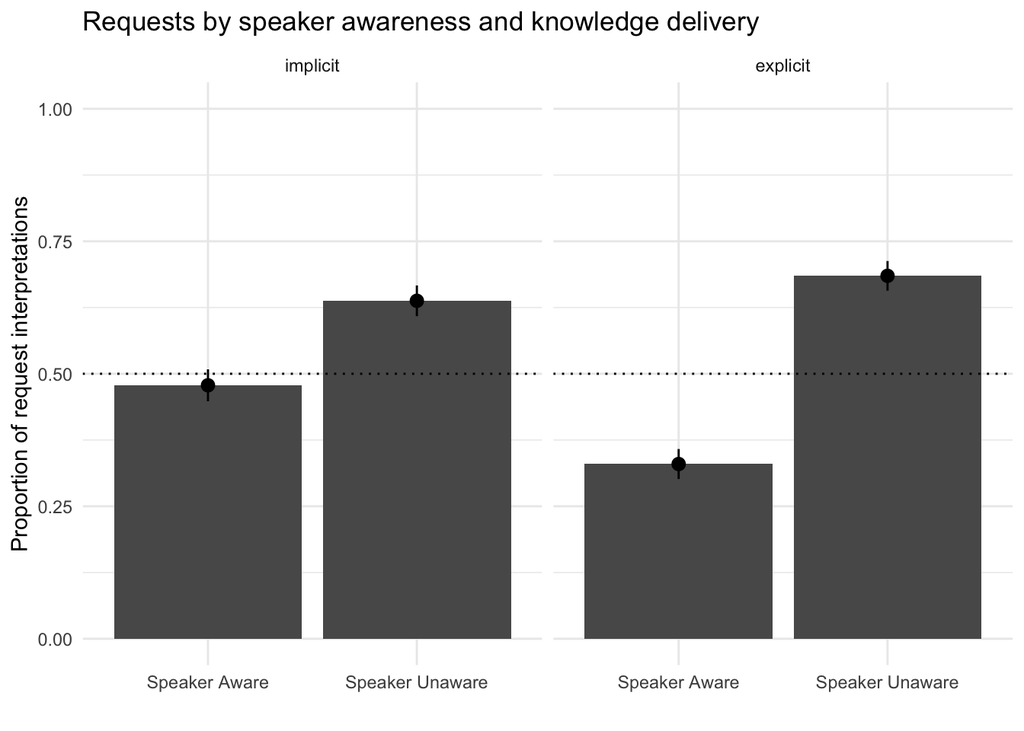

```r
main_plus_sst$knowledge <- factor(main_plus_sst$knowledge, levels = c("implicit", "explicit"))
main_plus_sst %>%
  ggplot(aes(x = Condition,
             y = numeric_code)) +
  # geom_bar(stat="summary", fun.y="mean", position="dodge", fill="#7293cb") +
  geom_bar(stat="summary", fun.y="mean", position="dodge") +
  theme_minimal() +
  stat_summary (fun.y = function(x){mean(x)},
                fun.ymin = function(x){mean(x) - 1*sd(x)/sqrt(length(x))},
                fun.ymax = function(x){mean(x) + 1*sd(x)/sqrt(length(x))},
                geom= 'pointrange',
                position=position_dodge(width=0.95)) +
  labs(x = "",
       y = "Proportion of request interpretations",
       title = "Requests by speaker awareness and knowledge delivery") +
  geom_hline(yintercept = .5, linetype = "dotted") +
  scale_y_continuous(limits=c(0, 1)) +
  facet_grid(~knowledge)
```

```r
ggsave("figures/exp5_knowledge_effect.tiff",
       units="in", width=6, height=4, dpi=300)
ggsave("/Users/seantrott/Dropbox/UCSD/Research/IndirectSpeechActs/presentations/CRL/Figures/exp5_knowledge_main_effect.pdf",
       units="in", width=6, height=4, dpi=300)
```

```r
model_all = glmer(data=main_plus_sst,
                  answer ~ stimType * knowledge +
                     (1  + stimType | subject) + (1 + stimType | stimNum) + (1 | group),
                  control=glmerControl(optimizer="bobyqa"),
                   family=binomial())
```

```
## boundary (singular) fit: see ?isSingular
```

```r
model_both = glmer(data=main_plus_sst, answer ~ stimType + knowledge +
                          (1  + stimType | subject) + (1 + stimType | stimNum) + (1 | group),
                   control=glmerControl(optimizer="bobyqa"),
                        family=binomial())
```

```
## boundary (singular) fit: see ?isSingular
```

```r
model_knowledge = glmer(data=main_plus_sst, answer ~ knowledge +
                          (1  + stimType | subject) + (1 + stimType | stimNum) + (1 | group),
                        control=glmerControl(optimizer="bobyqa"),
                        family=binomial())
```

```
## boundary (singular) fit: see ?isSingular
```

```r
model_awareness = glmer(data=main_plus_sst, answer ~ stimType +
                  (1  + stimType | subject) + (1 + stimType | stimNum) + (1 | group),
                  control=glmerControl(optimizer="bobyqa"),
                family=binomial())
```

```
## boundary (singular) fit: see ?isSingular
```

```r
model_null = glmer(data=main_plus_sst, answer ~ (1 + stimType | subject) +
                                  (1 + stimType | stimNum) + (1 | group),
                   control=glmerControl(optimizer="bobyqa"),
                  family=binomial())
```

```
## boundary (singular) fit: see ?isSingular
```

```r
anova(model_awareness, model_null)
```

```
## Data: main_plus_sst
## Models:
## model_null: answer ~ (1 + stimType | subject) + (1 + stimType | stimNum) +
## model_null:     (1 | group)
## model_awareness: answer ~ stimType + (1 + stimType | subject) + (1 + stimType |
## model_awareness:     stimNum) + (1 | group)
##                 Df    AIC    BIC  logLik deviance  Chisq Chi Df Pr(>Chisq)
## model_null       8 1354.4 1394.5 -669.21   1338.4
## model_awareness  9 1334.7 1379.8 -658.35   1316.7 21.739      1  3.123e-06
##
## model_null
## model_awareness ***
## ---
## Signif. codes:  0 '***' 0.001 '**' 0.01 '*' 0.05 '.' 0.1 ' ' 1
```

```r
anova(model_knowledge, model_null)
```

```
## Data: main_plus_sst
## Models:
## model_null: answer ~ (1 + stimType | subject) + (1 + stimType | stimNum) +
## model_null:     (1 | group)
## model_knowledge: answer ~ knowledge + (1 + stimType | subject) + (1 + stimType |
## model_knowledge:     stimNum) + (1 | group)
##                 Df    AIC    BIC  logLik deviance  Chisq Chi Df Pr(>Chisq)
## model_null       8 1354.4 1394.5 -669.21   1338.4
## model_knowledge  9 1352.2 1397.3 -667.10   1334.2 4.2299      1    0.03972
##
## model_null
## model_knowledge *
## ---
## Signif. codes:  0 '***' 0.001 '**' 0.01 '*' 0.05 '.' 0.1 ' ' 1
```

```r
anova(model_both, model_knowledge)
```

```
## Data: main_plus_sst
## Models:
## model_knowledge: answer ~ knowledge + (1 + stimType | subject) + (1 + stimType |
## model_knowledge:     stimNum) + (1 | group)
## model_both: answer ~ stimType + knowledge + (1 + stimType | subject) + (1 +
## model_both:     stimType | stimNum) + (1 | group)
##                 Df    AIC    BIC  logLik deviance  Chisq Chi Df Pr(>Chisq)
## model_knowledge  9 1352.2 1397.3 -667.10   1334.2
## model_both      10 1332.7 1382.8 -656.36   1312.7 21.483      1   3.57e-06
##
## model_knowledge
## model_both      ***
## ---
## Signif. codes:  0 '***' 0.001 '**' 0.01 '*' 0.05 '.' 0.1 ' ' 1
```

```r
anova(model_both, model_awareness)
```

```
## Data: main_plus_sst
## Models:
## model_awareness: answer ~ stimType + (1 + stimType | subject) + (1 + stimType |
## model_awareness:     stimNum) + (1 | group)
## model_both: answer ~ stimType + knowledge + (1 + stimType | subject) + (1 +
## model_both:     stimType | stimNum) + (1 | group)
##                 Df    AIC    BIC  logLik deviance  Chisq Chi Df Pr(>Chisq)
## model_awareness  9 1334.7 1379.8 -658.35   1316.7
## model_both      10 1332.7 1382.8 -656.36   1312.7 3.9735      1    0.04622
##
## model_awareness
## model_both      *
## ---
## Signif. codes:  0 '***' 0.001 '**' 0.01 '*' 0.05 '.' 0.1 ' ' 1
```

```r
anova(model_all, model_both)
```

```
## Data: main_plus_sst
## Models:
## model_both: answer ~ stimType + knowledge + (1 + stimType | subject) + (1 +
## model_both:     stimType | stimNum) + (1 | group)
## model_all: answer ~ stimType * knowledge + (1 + stimType | subject) + (1 +
## model_all:     stimType | stimNum) + (1 | group)
##            Df    AIC    BIC  logLik deviance  Chisq Chi Df Pr(>Chisq)
## model_both 10 1332.7 1382.8 -656.36   1312.7
## model_all  11 1322.5 1377.5 -650.24   1300.5 12.241      1  0.0004676 ***
## ---
## Signif. codes:  0 '***' 0.001 '**' 0.01 '*' 0.05 '.' 0.1 ' ' 1
```

According to the model comparisons, there is a main effect of **speaker knowledge** (more requests in the Speaker Unaware condition), a significant interaction between **speaker knowledge** and **knowledge delivery** (stronger impact of knowledge states on the *explicit* trials), and a weak effect of **knowledge delivery** (more requests on the *implicit* trials).

### Descriptive

```r
main_plus_sst %>%
  group_by(knowledge, Condition) %>%
  summarise(mean_request = mean(numeric_code),
            sd_request = sd(numeric_code))
```

```
## # A tibble: 4 x 4
## # Groups:   knowledge [?]
##   knowledge Condition       mean_request sd_request
##   <fct>     <chr>                  <dbl>      <dbl>
## 1 implicit  Speaker Aware          0.478      0.500
## 2 implicit  Speaker Unaware        0.638      0.482
## 3 explicit  Speaker Aware          0.330      0.471
## 4 explicit  Speaker Unaware        0.685      0.465
```

### Effect of order?

```r
model_order_all = glmer(data=main_plus_sst,
                        answer ~ stimType * order +
                  (1  + stimType | subject) + (1 + stimType | stimNum),
                  control=glmerControl(optimizer="bobyqa"),
                family=binomial())

model_order_all_reduced = glmer(data=main_plus_sst,
                        answer ~ stimType + order +
                  (1  + stimType | subject) + (1 + stimType | stimNum),
                  control=glmerControl(optimizer="bobyqa"),
                family=binomial())

anova(model_order_all, model_order_all_reduced)
```

```
## Data: main_plus_sst
## Models:
## model_order_all_reduced: answer ~ stimType + order + (1 + stimType | subject) + (1 + stimType |
## model_order_all_reduced:     stimNum)
## model_order_all: answer ~ stimType * order + (1 + stimType | subject) + (1 + stimType |
## model_order_all:     stimNum)
##                         Df    AIC    BIC  logLik deviance  Chisq Chi Df
## model_order_all_reduced  9 1334.6 1379.7 -658.30   1316.6
## model_order_all         10 1332.1 1382.2 -656.04   1312.1 4.5146      1
##                         Pr(>Chisq)
## model_order_all_reduced
## model_order_all            0.03361 *
## ---
## Signif. codes:  0 '***' 0.001 '**' 0.01 '*' 0.05 '.' 0.1 ' ' 1
```

```r
model_awareness_first = glmer(data=filter(main_plus_sst, order <= 1),
                        answer ~ stimType + (1 + stimType | stimNum),
                  control=glmerControl(optimizer="bobyqa"),
                family=binomial())
```

```
## boundary (singular) fit: see ?isSingular
```

```r
model_null_first = glmer(data=filter(main_plus_sst, order <= 1),
                   answer ~   (1 + stimType | stimNum),
                   control=glmerControl(optimizer="bobyqa"),
                  family=binomial())
```

```
## boundary (singular) fit: see ?isSingular
```

```r
anova(model_awareness_first, model_null_first)
```

```
## Data: filter(main_plus_sst, order <= 1)
## Models:
## model_null_first: answer ~ (1 + stimType | stimNum)
## model_awareness_first: answer ~ stimType + (1 + stimType | stimNum)
##                       Df    AIC    BIC  logLik deviance  Chisq Chi Df
## model_null_first       4 102.82 111.76 -47.412   94.823
## model_awareness_first  5 103.35 114.52 -46.675   93.350 1.4733      1
##                       Pr(>Chisq)
## model_null_first
## model_awareness_first     0.2248
```

```r
model_awareness_first = glmer(data=filter(main_plus_sst, order <= 1 & knowledge == "explicit"),
                        answer ~ stimType + (1 | stimNum),
                  control=glmerControl(optimizer="bobyqa"),
                family=binomial())
```

```
## boundary (singular) fit: see ?isSingular
```

```r
model_null_first = glmer(data=filter(main_plus_sst, order <= 1& knowledge == "explicit"),
                   answer ~   (1 | stimNum),
                   control=glmerControl(optimizer="bobyqa"),
                  family=binomial())
```

```
## boundary (singular) fit: see ?isSingular
```

```r
anova(model_awareness_first, model_null_first)
```

```
## Data: filter(main_plus_sst, order <= 1 & knowledge == "explicit")
## Models:
## model_null_first: answer ~ (1 | stimNum)
## model_awareness_first: answer ~ stimType + (1 | stimNum)
##                       Df    AIC    BIC  logLik deviance  Chisq Chi Df
## model_null_first       2 45.455 48.258 -20.728   41.455
## model_awareness_first  3 42.493 46.696 -18.246   36.493 4.9625      1
##                       Pr(>Chisq)
## model_null_first
## model_awareness_first     0.0259 *
## ---
## Signif. codes:  0 '***' 0.001 '**' 0.01 '*' 0.05 '.' 0.1 ' ' 1
```

```r
model_awareness_first = glmer(data=filter(main_plus_sst, order <= 1 & knowledge == "implicit"),
                        answer ~ stimType + (1 | stimNum),
                  control=glmerControl(optimizer="bobyqa"),
                family=binomial())
```

```
## boundary (singular) fit: see ?isSingular
```

```r
model_null_first = glmer(data=filter(main_plus_sst, order <= 1& knowledge == "implicit"),
                   answer ~   (1 | stimNum),
                   control=glmerControl(optimizer="bobyqa"),
                  family=binomial())
```

```
## boundary (singular) fit: see ?isSingular
```

```r
anova(model_awareness_first, model_null_first)
```

```
## Data: filter(main_plus_sst, order <= 1 & knowledge == "implicit")
## Models:
## model_null_first: answer ~ (1 | stimNum)
## model_awareness_first: answer ~ stimType + (1 | stimNum)
##                       Df    AIC    BIC  logLik deviance Chisq Chi Df
## model_null_first       2 58.040 61.367 -27.020   54.040
## model_awareness_first  3 60.013 65.004 -27.006   54.013 0.027      1
##                       Pr(>Chisq)
## model_null_first
## model_awareness_first     0.8695
```

## Does mentalizing predict the impact of speaker knowledge?

We also want to know whether **mentalizing** predicts a participant’s likelihood of making a response *congruent* with what a speaker knows.

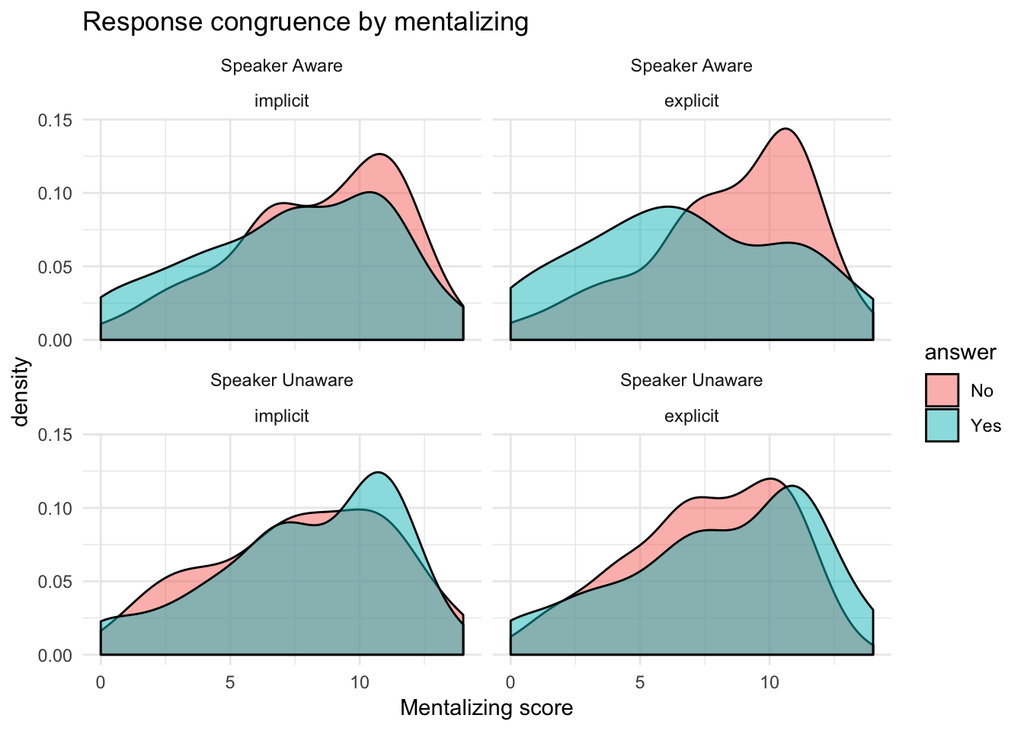

```r
main_plus_sst$Congruent = (main_plus_sst$Condition == "Speaker Unaware" & main_plus_sst$answer == "Yes") |
  (main_plus_sst$Condition == "Speaker Aware" & main_plus_sst$answer == "No")

main_plus_sst$Congruence = fct_recode(as.character(main_plus_sst$Congruent),
                                     "congruent" = "TRUE",
                                     "incongruent" = "FALSE")

main_plus_sst$order_binned = cut(main_plus_sst$order,
                                 breaks=c(0, 4, 8, 12, 17),
                                 labels=c("first", "second", "third", "fourth"))

main_plus_sst %>%
  ggplot(aes(x=exp_inf_mean, fill=answer)) +
  geom_density(alpha=.5) +
  theme_minimal() +
  # scale_fill_manual(values = c("congruent" = "seagreen2", "incongruent" = "tomato1")) +
  xlab("Mentalizing score") +
  ggtitle("Response congruence by mentalizing") +
  facet_wrap(~Condition + knowledge, ncol = 2)
```

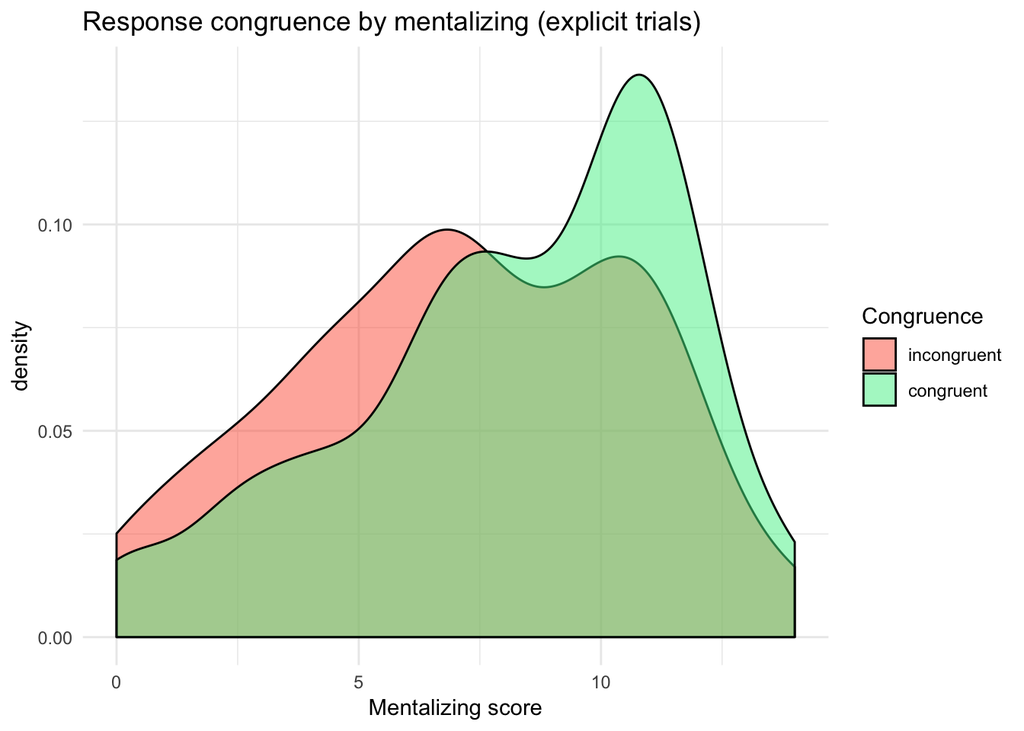

```r
main_plus_sst %>%
  filter(knowledge == "explicit") %>%
  ggplot(aes(x=exp_inf_mean, fill=Congruence)) +
  geom_density(alpha=.5) +
  theme_minimal() +
  scale_fill_manual(values = c("congruent" = "seagreen2", "incongruent" = "tomato1")) +
  labs(x = "Mentalizing score",
       title = "Response congruence by mentalizing (explicit trials)")
```

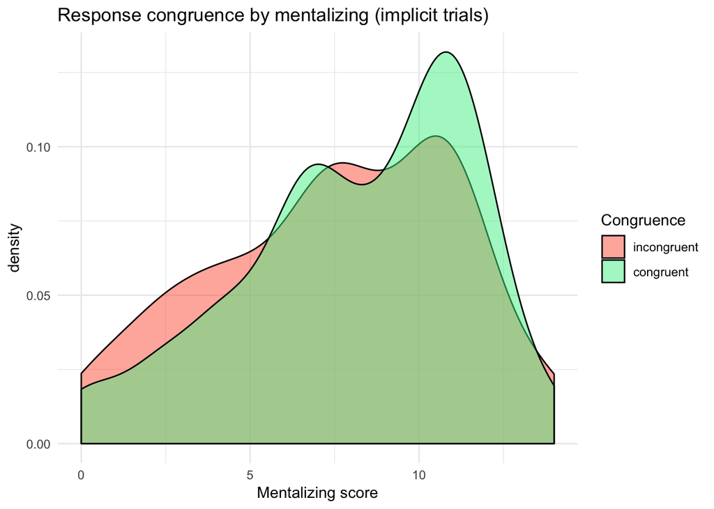

```r
ggsave("/Users/seantrott/Dropbox/UCSD/Research/IndirectSpeechActs/presentations/CRL/Figures/exp5_mentalizing_explicit.tiff",
       units="in", width=6, height=4, dpi=300, compression = 'lzw')

main_plus_sst %>%
  filter(knowledge == "implicit") %>%
  ggplot(aes(x=exp_inf_mean, fill=Congruence)) +
  geom_density(alpha=.5) +
  theme_minimal() +
  scale_fill_manual(values = c("congruent" = "seagreen2", "incongruent" = "tomato1")) +
  labs(x = "Mentalizing score",
       title = "Response congruence by mentalizing (implicit trials)")
```

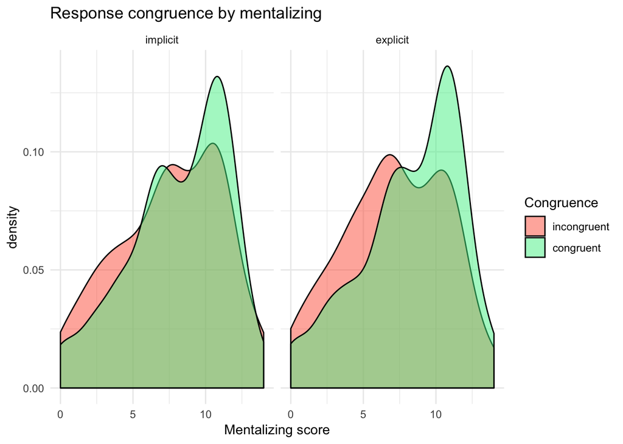

```r
ggsave("/Users/seantrott/Dropbox/UCSD/Research/IndirectSpeechActs/presentations/CRL/Figures/exp5_mentalizing_implicit.tiff",
       units="in", width=6, height=4, dpi=300, compression = 'lzw')

main_plus_sst %>%
  ggplot(aes(x=exp_inf_mean, fill=Congruence)) +
  geom_density(alpha=.5) +
  theme_minimal() +
  scale_fill_manual(values = c("congruent" = "seagreen2", "incongruent" = "tomato1")) +
  xlab("Mentalizing score") +
  ggtitle("Response congruence by mentalizing") +
  facet_wrap(~knowledge, ncol = 2)
```

### Building and comparing models

```r
mixed.logit.all.three = glmer(answer ~ Condition * exp_inf_mean * knowledge +
                          Condition * rc_bins_1 * knowledge +
                          (1 + Condition | stimNum),
                        data = main_plus_sst,
                        control=glmerControl(optimizer="bobyqa"),
                        family=binomial)

mixed.logit.all.three.reduced = glmer(answer ~ Condition * exp_inf_mean + Condition * knowledge + exp_inf_mean * knowledge +
                          Condition * rc_bins_1 * knowledge +
                          (1 + Condition | stimNum),
                        data = main_plus_sst,
                        control=glmerControl(optimizer="bobyqa"),
                        family=binomial)

mixed.logit.just.explicit = glmer(answer ~ Condition * exp_inf_mean +
                          Condition * rc_bins_1 +
                          (1 + Condition | stimNum),
                        data = filter(main_plus_sst, knowledge == "explicit"),
                        control=glmerControl(optimizer="bobyqa"),
                        family=binomial)
```

```
## boundary (singular) fit: see ?isSingular
```

```r
mixed.logit.just.explicit.reduced = glmer(answer ~ Condition + exp_inf_mean +
                          Condition * rc_bins_1 +
                          (1 + Condition | stimNum),
                        data = filter(main_plus_sst, knowledge == "explicit"),
                        control=glmerControl(optimizer="bobyqa"),
                        family=binomial)
```

```
## boundary (singular) fit: see ?isSingular
```

```r
mixed.logit.just.implicit = glmer(answer ~ Condition * exp_inf_mean +
                          Condition * rc_bins_1 +
                          (1 + Condition | stimNum),
                        data = filter(main_plus_sst, knowledge == "implicit"),
                        control=glmerControl(optimizer="bobyqa"),
                        family=binomial)

mixed.logit.just.implicit.reduced = glmer(answer ~ Condition + exp_inf_mean +
                          Condition * rc_bins_1 +
                          (1 + Condition | stimNum),
                        data = filter(main_plus_sst, knowledge == "implicit"),
                        control=glmerControl(optimizer="bobyqa"),
                        family=binomial)

mixed.logit.all = glmer(answer ~ Condition * exp_inf_mean +
                          Condition * rc_bins_1 +
                          (1 + Condition | stimNum),
                        data = main_plus_sst,
                        control=glmerControl(optimizer="bobyqa"),
                        family=binomial)

mixed.logit.reduced = glmer(answer ~ Condition + exp_inf_mean +
                          Condition * rc_bins_1 +
                          (1 + Condition | stimNum),
                        data = main_plus_sst,
                        control=glmerControl(optimizer="bobyqa"),
                        family=binomial)

mixed.logit.reduced.rc = glmer(answer ~ Condition * exp_inf_mean +
                              Condition + rc_bins_1 +
                              (1 + Condition | stimNum),
                            data = main_plus_sst,
                            control=glmerControl(optimizer="bobyqa"),
                            family=binomial)

mixed.logit.rc = glmer(answer ~ Condition * rc_bins_1 +
                          (1 + Condition | stimNum),
                        data = main_plus_sst,
                        control=glmerControl(optimizer="bobyqa"),
                        family=binomial)

mixed.logit.rc.reduced = glmer(answer ~ Condition + rc_bins_1 +
                                  (1 + Condition | stimNum),
                                data = main_plus_sst,
                                control=glmerControl(optimizer="bobyqa"),
                                family=binomial)

mixed.logit.inf = glmer(answer ~ Condition * exp_inf_mean +
                          (1 + Condition | stimNum),
                        data = main_plus_sst,
                        control=glmerControl(optimizer="bobyqa"),
                        family=binomial)

mixed.logit.inf.reduced = glmer(answer ~ Condition + exp_inf_mean +
                                  (1 + Condition | stimNum),
                                data = main_plus_sst,
                                control=glmerControl(optimizer="bobyqa"),
                                family=binomial)
```

```r
anova(mixed.logit.just.implicit, mixed.logit.just.implicit.reduced)
```

```
## Data: filter(main_plus_sst, knowledge == "implicit")
## Models:
## mixed.logit.just.implicit.reduced: answer ~ Condition + exp_inf_mean + Condition * rc_bins_1 + (1 +
## mixed.logit.just.implicit.reduced:     Condition | stimNum)
## mixed.logit.just.implicit: answer ~ Condition * exp_inf_mean + Condition * rc_bins_1 + (1 +
## mixed.logit.just.implicit:     Condition | stimNum)
##                                   Df    AIC    BIC  logLik deviance  Chisq
## mixed.logit.just.implicit.reduced  8 728.95 763.45 -356.47   712.95
## mixed.logit.just.implicit          9 728.50 767.33 -355.25   710.50 2.4414
##                                   Chi Df Pr(>Chisq)
## mixed.logit.just.implicit.reduced
## mixed.logit.just.implicit              1     0.1182
```

```r
anova(mixed.logit.just.explicit, mixed.logit.just.explicit.reduced)
```

```
## Data: filter(main_plus_sst, knowledge == "explicit")
## Models:
## mixed.logit.just.explicit.reduced: answer ~ Condition + exp_inf_mean + Condition * rc_bins_1 + (1 +
## mixed.logit.just.explicit.reduced:     Condition | stimNum)
## mixed.logit.just.explicit: answer ~ Condition * exp_inf_mean + Condition * rc_bins_1 + (1 +
## mixed.logit.just.explicit:     Condition | stimNum)
##                                   Df    AIC    BIC  logLik deviance  Chisq
## mixed.logit.just.explicit.reduced  8 680.68 715.19 -332.34   664.68
## mixed.logit.just.explicit          9 673.56 712.38 -327.78   655.56 9.1179
##                                   Chi Df Pr(>Chisq)
## mixed.logit.just.explicit.reduced
## mixed.logit.just.explicit              1   0.002531 **
## ---
## Signif. codes:  0 '***' 0.001 '**' 0.01 '*' 0.05 '.' 0.1 ' ' 1
```

```r
anova(mixed.logit.all.three, mixed.logit.all.three.reduced)
```

```
## Data: main_plus_sst
## Models:
## mixed.logit.all.three.reduced: answer ~ Condition * exp_inf_mean + Condition * knowledge + exp_inf_mean *
## mixed.logit.all.three.reduced:     knowledge + Condition * rc_bins_1 * knowledge + (1 + Condition |
## mixed.logit.all.three.reduced:     stimNum)
## mixed.logit.all.three: answer ~ Condition * exp_inf_mean * knowledge + Condition * rc_bins_1 *
## mixed.logit.all.three:     knowledge + (1 + Condition | stimNum)
##                               Df    AIC    BIC  logLik deviance  Chisq
## mixed.logit.all.three.reduced 14 1375.5 1445.6 -673.77   1347.5
## mixed.logit.all.three         15 1376.1 1451.2 -673.05   1346.1 1.4428
##                               Chi Df Pr(>Chisq)
## mixed.logit.all.three.reduced
## mixed.logit.all.three              1     0.2297
```

```r
anova(mixed.logit.all, mixed.logit.reduced)
```

```
## Data: main_plus_sst
## Models:
## mixed.logit.reduced: answer ~ Condition + exp_inf_mean + Condition * rc_bins_1 + (1 +
## mixed.logit.reduced:     Condition | stimNum)
## mixed.logit.all: answer ~ Condition * exp_inf_mean + Condition * rc_bins_1 + (1 +
## mixed.logit.all:     Condition | stimNum)
##                     Df    AIC    BIC  logLik deviance  Chisq Chi Df
## mixed.logit.reduced  8 1388.5 1428.6 -686.25   1372.5
## mixed.logit.all      9 1380.2 1425.3 -681.10   1362.2 10.312      1
##                     Pr(>Chisq)
## mixed.logit.reduced
## mixed.logit.all       0.001321 **
## ---
## Signif. codes:  0 '***' 0.001 '**' 0.01 '*' 0.05 '.' 0.1 ' ' 1
```

```r
anova(mixed.logit.all, mixed.logit.reduced.rc)
```

```
## Data: main_plus_sst
## Models:
## mixed.logit.reduced.rc: answer ~ Condition * exp_inf_mean + Condition + rc_bins_1 + (1 +
## mixed.logit.reduced.rc:     Condition | stimNum)
## mixed.logit.all: answer ~ Condition * exp_inf_mean + Condition * rc_bins_1 + (1 +
## mixed.logit.all:     Condition | stimNum)
##                        Df    AIC    BIC  logLik deviance Chisq Chi Df
## mixed.logit.reduced.rc  8 1379.6 1419.7 -681.81   1363.6
## mixed.logit.all         9 1380.2 1425.3 -681.10   1362.2 1.413      1
##                        Pr(>Chisq)
## mixed.logit.reduced.rc
## mixed.logit.all            0.2346
```

```r
anova(mixed.logit.inf, mixed.logit.inf.reduced)
```

```
## Data: main_plus_sst
## Models:
## mixed.logit.inf.reduced: answer ~ Condition + exp_inf_mean + (1 + Condition | stimNum)
## mixed.logit.inf: answer ~ Condition * exp_inf_mean + (1 + Condition | stimNum)
##                         Df    AIC    BIC  logLik deviance  Chisq Chi Df
## mixed.logit.inf.reduced  6 1395.6 1425.6 -691.79   1383.6
## mixed.logit.inf          7 1379.6 1414.7 -682.82   1365.6 17.942      1
##                         Pr(>Chisq)
## mixed.logit.inf.reduced
## mixed.logit.inf          2.277e-05 ***
## ---
## Signif. codes:  0 '***' 0.001 '**' 0.01 '*' 0.05 '.' 0.1 ' ' 1
```

```r
anova(mixed.logit.rc, mixed.logit.rc.reduced)
```

```
## Data: main_plus_sst
## Models:
## mixed.logit.rc.reduced: answer ~ Condition + rc_bins_1 + (1 + Condition | stimNum)
## mixed.logit.rc: answer ~ Condition * rc_bins_1 + (1 + Condition | stimNum)
##                        Df    AIC    BIC  logLik deviance  Chisq Chi Df
## mixed.logit.rc.reduced  6 1395.5 1425.6 -691.77   1383.5
## mixed.logit.rc          7 1388.4 1423.4 -687.20   1374.4 9.1344      1
##                        Pr(>Chisq)
## mixed.logit.rc.reduced
## mixed.logit.rc           0.002508 **
## ---
## Signif. codes:  0 '***' 0.001 '**' 0.01 '*' 0.05 '.' 0.1 ' ' 1
```

```r
mixed.logit.spon = glmer(answer ~ Condition * factor(spon_true) +
                                  (1 + Condition | stimNum),
                                data = filter(main_plus_sst, knowledge=="implicit"),
                                control=glmerControl(optimizer="bobyqa"),
                                family=binomial)

mixed.logit.spon.reduced = glmer(answer ~ Condition + factor(spon_true) +
                                  (1 + Condition | stimNum),
                                data = filter(main_plus_sst, knowledge=="implicit"),
                                control=glmerControl(optimizer="bobyqa"),
                                family=binomial)

anova(mixed.logit.spon, mixed.logit.spon.reduced)
```

```
## Data: filter(main_plus_sst, knowledge == "implicit")
## Models:
## mixed.logit.spon.reduced: answer ~ Condition + factor(spon_true) + (1 + Condition | stimNum)
## mixed.logit.spon: answer ~ Condition * factor(spon_true) + (1 + Condition | stimNum)
##                          Df    AIC    BIC  logLik deviance  Chisq Chi Df
## mixed.logit.spon.reduced  6 730.36 756.24 -359.18   718.36
## mixed.logit.spon          7 731.46 761.66 -358.73   717.46 0.8953      1
##                          Pr(>Chisq)
## mixed.logit.spon.reduced
## mixed.logit.spon              0.344
```

```r
mixed.logit.spon = glmer(answer ~ Condition * factor(spon_true) +
                                  (1 + Condition | stimNum),
                                data = filter(main_plus_sst, knowledge=="explicit"),
                                control=glmerControl(optimizer="bobyqa"),
                                family=binomial)
```

```
## boundary (singular) fit: see ?isSingular
```

```r
mixed.logit.spon.reduced = glmer(answer ~ Condition + factor(spon_true) +
                                  (1 + Condition | stimNum),
                                data = filter(main_plus_sst, knowledge=="explicit"),
                                control=glmerControl(optimizer="bobyqa"),
                                family=binomial)
```

```
## boundary (singular) fit: see ?isSingular
```

```r
anova(mixed.logit.spon, mixed.logit.spon.reduced)
```

```
## Data: filter(main_plus_sst, knowledge == "explicit")
## Models:
## mixed.logit.spon.reduced: answer ~ Condition + factor(spon_true) + (1 + Condition | stimNum)
## mixed.logit.spon: answer ~ Condition * factor(spon_true) + (1 + Condition | stimNum)
##                          Df    AIC    BIC  logLik deviance  Chisq Chi Df
## mixed.logit.spon.reduced  6 687.19 713.07 -337.59   675.19
## mixed.logit.spon          7 686.90 717.10 -336.45   672.90 2.2856      1
##                          Pr(>Chisq)
## mixed.logit.spon.reduced
## mixed.logit.spon             0.1306
```

```r
mixed.logit.spon.full = glmer(answer ~ Condition * factor(spon_true) + Condition * rc_bins_1 +
                                  (1 + Condition | stimNum),
                                data = main_plus_sst,
                                control=glmerControl(optimizer="bobyqa"),
                                family=binomial)

mixed.logit.spon.full.reduced = glmer(answer ~ Condition + factor(spon_true) + Condition * rc_bins_1 +
                                  (1 + Condition | stimNum),
                                data = main_plus_sst,
                                control=glmerControl(optimizer="bobyqa"),
                                family=binomial)


mixed.logit.spon = glmer(answer ~ Condition * factor(spon_true) +
                                  (1 + Condition | stimNum),
                                data = main_plus_sst,
                                control=glmerControl(optimizer="bobyqa"),
                                family=binomial)

mixed.logit.spon.reduced = glmer(answer ~ Condition + factor(spon_true) +
                                  (1 + Condition | stimNum),
                                data = main_plus_sst,
                                control=glmerControl(optimizer="bobyqa"),
                                family=binomial)

anova(mixed.logit.spon.full, mixed.logit.spon.full.reduced)
```

```
## Data: main_plus_sst
## Models:
## mixed.logit.spon.full.reduced: answer ~ Condition + factor(spon_true) + Condition * rc_bins_1 +
## mixed.logit.spon.full.reduced:     (1 + Condition | stimNum)
## mixed.logit.spon.full: answer ~ Condition * factor(spon_true) + Condition * rc_bins_1 +
## mixed.logit.spon.full:     (1 + Condition | stimNum)
##                               Df    AIC    BIC  logLik deviance  Chisq
## mixed.logit.spon.full.reduced  8 1390.2 1430.2 -687.08   1374.2
## mixed.logit.spon.full          9 1390.5 1435.6 -686.27   1372.5 1.6281
##                               Chi Df Pr(>Chisq)
## mixed.logit.spon.full.reduced
## mixed.logit.spon.full              1      0.202
```

```r
anova(mixed.logit.spon, mixed.logit.spon.reduced)
```

```
## Data: main_plus_sst
## Models:
## mixed.logit.spon.reduced: answer ~ Condition + factor(spon_true) + (1 + Condition | stimNum)
## mixed.logit.spon: answer ~ Condition * factor(spon_true) + (1 + Condition | stimNum)
##                          Df    AIC    BIC  logLik deviance  Chisq Chi Df
## mixed.logit.spon.reduced  6 1400.2 1430.3 -694.11   1388.2
## mixed.logit.spon          7 1399.3 1434.3 -692.63   1385.3 2.9663      1
##                          Pr(>Chisq)
## mixed.logit.spon.reduced
## mixed.logit.spon            0.08501 .
## ---
## Signif. codes:  0 '***' 0.001 '**' 0.01 '*' 0.05 '.' 0.1 ' ' 1
```

# Summary

Main findings:

- **Speaker knowledge** significantly predicted **pragmatic interpretation**.
- **Knowledge delivery** (explicit / implicit) affected the rate at which knowledge predicted interpretation, providing evidence for *sampling loss*. However, the fact that accuracy rates were not 100% in the *explicit* condition (far from it) suggests that there is also a *lossy conversion* in *deploying* information about what a speaker knows for pragmatic inference.
- **Mentalizing** predicted a comprehender’s likelihood of interpreting an utterance consistent with what a speaker could be inferred to know overall. There was not a significant *difference* in the effect of mentalizing on the implicit vs. explicit trials (as measured by the 3-way interaction between speaker knowledge, knowledge delivery, and mentalizing).
- However, when breaking it down by trial type, **mentalizing** was only strongly significant in the *explicit trials*; the effect in the implicit trials was weakly suggestive at best (p=.1). In other words, mentalizing predicts rate of deployment when knowledge is given explicitly, but not the combined rate of sampling and deployment when knowledge is given implicitly.